# 텍스트 수집 및 키워드 분석

## 한글 폰트 설정

- 실행 후 런타임 재시작 필요

```python
!sudo apt-get install -y fonts-nanum
!sudo fc-cache -fv
!rm ~/.cache/matplotlib -rf
```

```python
import matplotlib.pyplot as plt

plt.rc('font', family='NanumBarunGothic')
```

```python
import matplotlib as mpl
```

## 한국어 형태소 분석기 설치

- 한국어 자연어 처리 konlpy 라이브러리
- 형태소 분석기 MeCab 설치
- 설치 명령어:

`!curl -s https://raw.githubusercontent.com/teddylee777/machine-learning/master/99-Misc/01-Colab/mecab-colab.sh | bash`

```python
!curl -s https://raw.githubusercontent.com/teddylee777/machine-learning/master/99-Misc/01-Colab/mecab-colab.sh | bash
```

## 키워드 분석(Keyword Analysis)

- 핵심어(keyword)란 텍스트 자료의 중요한 내용을 압축적으로 제시하는 단어 또는 문구
- 핵심어 분석이란 불용어 제거와 어간추출 및 형태소 분석 등의 자연어 처리를 시행한 후 텍스트에서 많이 등장하는 형태소의 등장 빈도를 분석함으로써 핵심어를 추출
- 특정 텍스트 자료에 많이 나타나는 형태소가 그 텍스트 주제를 표출할 가능성이 높다는 가정에 기초
- 물론 빈도 분석에서 영어의 전치사나 한국어의 조사와 같이 의미를 별로 담고 있지 않은 불용어는 제외하는 것이 좋음
- 키워드 분석은 텍스트의 주제 추정, 텍스트 유사도, 검색 엔진의 검색 결과 우선 순위 측정 등 다양하게 사용될 수 있음

### 네이버 영화 리뷰 데이터

- 키워드 분석에는 네이버 영화 리뷰 데이터를 사용
- 데이터 다운로드: https://raw.githubusercontent.com/e9t/nsmc/master/ratings.txt

```python
import urllib.request

raw = urllib.request.urlopen('https://raw.githubusercontent.com/e9t/nsmc/master/ratings.txt').readlines()
print(raw[:5])
```

```
[b'id\tdocument\tlabel\n', b'8112052\t\xec\x96\xb4\xeb\xa6\xb4\xeb\x95\x8c\xeb\xb3\xb4\xea\xb3\xa0 \xec\xa7\x80\xea\xb8\x88\xeb\x8b\xa4\xec\x8b\x9c\xeb\xb4\x90\xeb\x8f\x84 \xec\x9e\xac\xeb\xb0\x8c\xec\x96\xb4\xec\x9a\x94\xe3\x85\x8b\xe3\x85\x8b\t1\n', b'8132799\t\xeb\x94\x94\xec\x9e\x90\xec\x9d\xb8\…
```

- 데이터를 확인해보면 모두 바이트로 이루어져 있으며, 리뷰 외의 다른 데이터도 존재
- 데이터를 문자열로 변환하고 리뷰만 추출

```python
raw = [x.decode() for x in raw[1:]]

decoded = []
for i in raw:
  decoded.append(i.split('\t'))

print(decoded[0])
```

```
['8112052', '어릴때보고 지금다시봐도 재밌어요ㅋㅋ', '1\n']
```

```python
reviews = []
for r in decoded:
  reviews.append(r[1])

print(reviews[0])
```

```
어릴때보고 지금다시봐도 재밌어요ㅋㅋ
```

### 형태소 분석을 이용한 명사 추출

- 형태소 분석기 Mecab으로 명사만 추출

```python
from konlpy.tag import Mecab

tagger = Mecab()

reviews_nouns = []
for review in reviews:
  for noun in tagger.nouns(review):
    reviews_nouns.append(noun)

reviews_nouns[:5]
```

```
['때', '디자인', '학생', '외국', '디자이너']
```

#### 불용어(Stopwords) 사전 만들기

- 형태소 분석을 통해 조사, 접속사 등의 제거 가능
- 하지만 한국어는 명사에서도 상당히 많은 불필요한 단어들이 포함
- 사용자가 직접 불용어 사전을 유지하면서 불필요한 단어 제거 필요
- 불용어 예: `전 난 일 걸 뭐 줄 만 건 분 개 끝 잼 이거 번 중 듯 때 게 내 말 나 수 거 점 것 후 이 애 씨 속 뿐 밋 그 급 ㄷ 데`
- 빈도가 너무 커서 분석에 방해되는 단어도 제거 필요 (예: `영화`)

```python
stop_words = '영화 전 난 일 걸 뭐 줄 만 건 분 개 끝 잼 이거 번 중 듯 때 게 내 말 나 수 거 점 것 후 이 애 씨 속 뿐 밋 그 급 ㄷ 데'
stop_words = stop_words.split(' ')
print(stop_words)
```

```
['영화', '전', '난', '일', '걸', '뭐', '줄', '만', '건', '분', '개', '끝', '잼', '이거', '번', '중', '듯', '때', '게', '내', '말', '나', '수', '거', '점', '것', '후', '이', '애', '씨', '속', '뿐', '밋', '그', '급', 'ㄷ', '데']
```

#### 불용어를 제외하여 형태소 분석 수행

- 한글 텍스트에 대해서 형태소 분석 수행
- 분석으로 추출하는 명사 중에서 불용어에 포함되지 않은 텍스트만 추출하여 저장

```python
reviews_nouns = []

for review in reviews:
  for noun in tagger.nouns(review):
    if noun not in stop_words:
      reviews_nouns.append(noun)

print(reviews_nouns[:5])
```

```
['디자인', '학생', '외국', '디자이너', '전통']
```

### 단어 빈도수 측정

- 단어 빈도수 측정에는 `collections` 라이브러리의 `Counter` 함수를 이용
- `collections` 라이브러리는 내장 라이브러리로 별도 설치가 필요없음
- `counter`를 이용하면 각 단어와 각 단어의 빈도 수를 딕셔너리로 편리하게 생성 가능

#### **`Counter(단어리스트)`** : Counter 객체

#### **`Counter객체.most_common(n)`** : 빈도가 가장 높은 n개의 단어

```python
from collections import Counter

reviews_nouns_counter = Counter(reviews_nouns)
top_reviews_nouns = dict(reviews_nouns_counter.most_common(10))
print(top_reviews_nouns)
```

```
{'연기': 9175, '최고': 8813, '평점': 8514, '스토리': 7163, '생각': 6943, '드라마': 6896, '사람': 6742, '감동': 6489, '배우': 5893, '내용': 5731}
```

### 단어 빈도 시각화

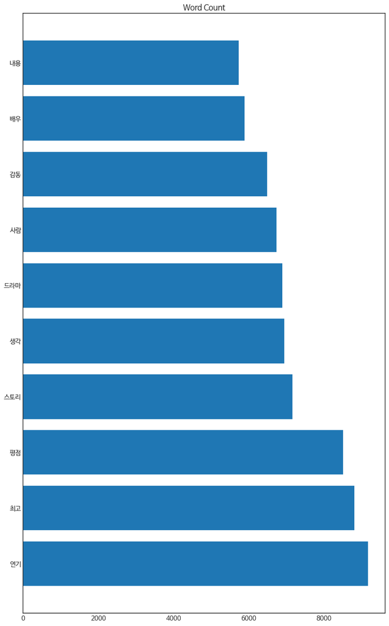

```python
import numpy as np

plt.rcParams['font.size'] = 12

y_pos = np.arange(len(top_reviews_nouns))

plt.figure(figsize = (12, 20))
plt.barh(y_pos, top_reviews_nouns.values())
plt.title('Word Count')
plt.yticks(y_pos, top_reviews_nouns.keys())
plt.show()
```

### 트리맵(Treemap) 시각화

- `squarify`는 트리맵 생성을 지원해주는 파이썬 라이브러리
- `squarify` 라이브러리를 이용해 키워드와 키워드 빈도 수를 트리맵으로 나타냄

#### **`squarify.plot(label, sizes, color, alpha)`**

```python
!pip install squarify
```

```python
import squarify

plt.rcParams['figure.figsize'] = (14, 14)
plt.rcParams['font.size'] = 20

norm = mpl.colors.Normalize(vmin = min(top_reviews_nouns.values()),
                            vmax = max(top_reviews_nouns.values()))
color = [mpl.cm.Reds(norm(value)) for value in top_reviews_nouns.values()]
```

```python
print(top_reviews_nouns)
```

```
{'연기': 9175, '최고': 8813, '평점': 8514, '스토리': 7163, '생각': 6943, '드라마': 6896, '사람': 6742, '감동': 6489, '배우': 5893, '내용': 5731}
```

```python
print(len(top_reviews_nouns.keys()))
print(len(top_reviews_nouns.values()))
print(len(color))
```

```
10
10
10
```

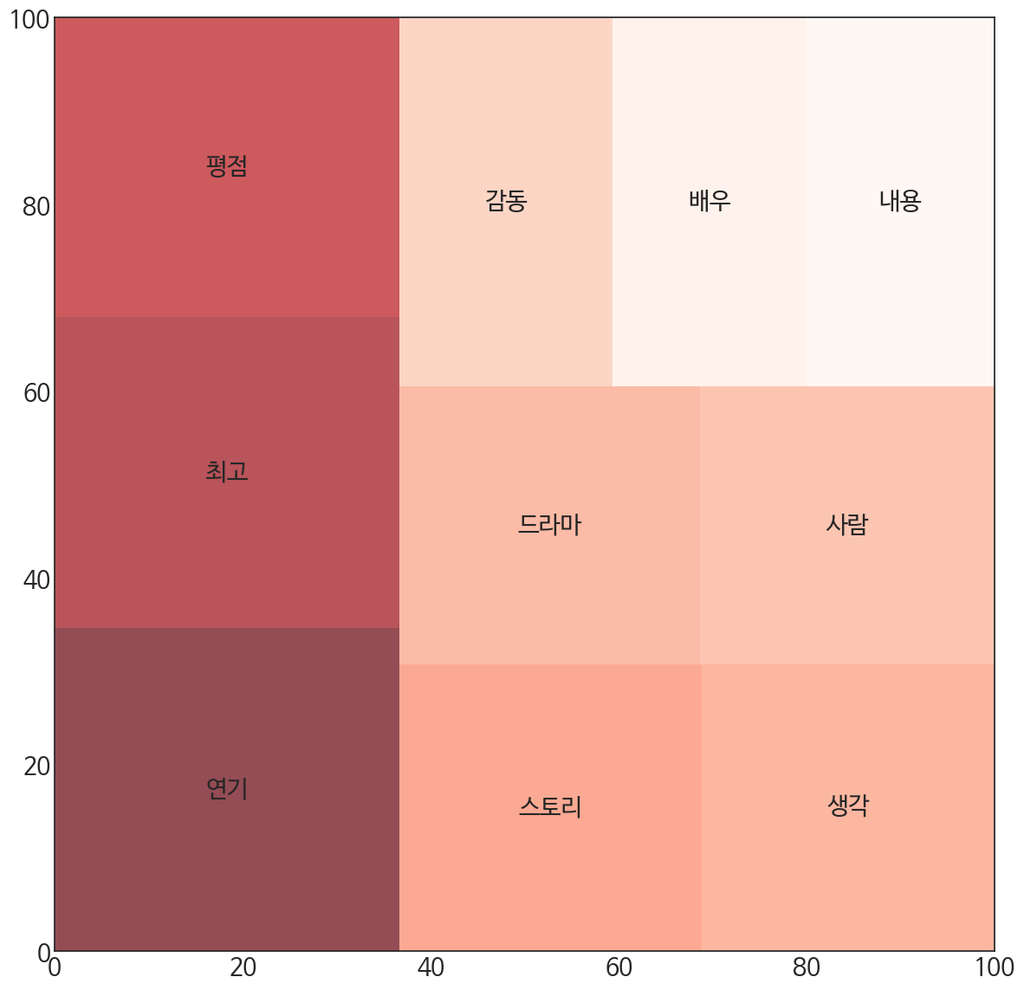

```python
squarify.plot(label = top_reviews_nouns.keys(),
              sizes = top_reviews_nouns.values(),
              color = color,
              alpha = .7)
```

### 워드클라우드(WordCloud) 시각화

- 텍스트에 담겨있는 여러 형태소들의 등장 빈도를 가장 직관적으로 시각화하는 방법
- 텍스트에 등장하는 단어를 그 등장 빈도에 따라 서로 크기가 다르게 구름 형태로 표현함으로써, 단어의 빈도 수를 한번에 알 수 있음
- 최근에 많은 서비스들이 어떤 핵심어가 많이 등장했는가를 워드클라우드 형식으로 시각화
- 빈도 수만을 시각적으로 표현한 것이기 때문에, 단어들 사이의 연관성이나 의미 구조 등을 분석하는 데는 한계가 있음
- 파이썬에서 워드 클라우드를 시각화하기 위해 `matplotlib` 라이브러리와 `WordCloud` 라이브러리를 `import` 해서 사용
- `WordCloud` 라이브러리는 `pip install wordcloud` 명령어를 통해 설치 필요

```python
!pip install wordcloud
```

- WordCloud를 이용해 객체를 생성해주고,

`generate_from_frequencies()` 함수로 빈도 수에 따라 워드클라우드 생성

#### **`WordCloud(backgroud_color, font_path)`** : 워드클라우드 객체

- `background_color` : 배경색
- `font_path` : 글씨체

#### **`'워드클라우드 객체'.generate_from_frequencies(단어빈도 딕셔너리)`** : 빈도기반 워드클라우드 생성

```python
from wordcloud import WordCloud

wc = WordCloud(background_color = 'white', font_path = '/font/NanumBarunGothic.ttf')
wc.generate_from_frequencies(top_reviews_nouns)
```

```
<wordcloud.wordcloud.WordCloud at 0x7f7d09af5c70>
```

- 워드클라우드를 시각화할 때는 이미지 시각화 함수인 `imshow()` 함수를 사용해야 함

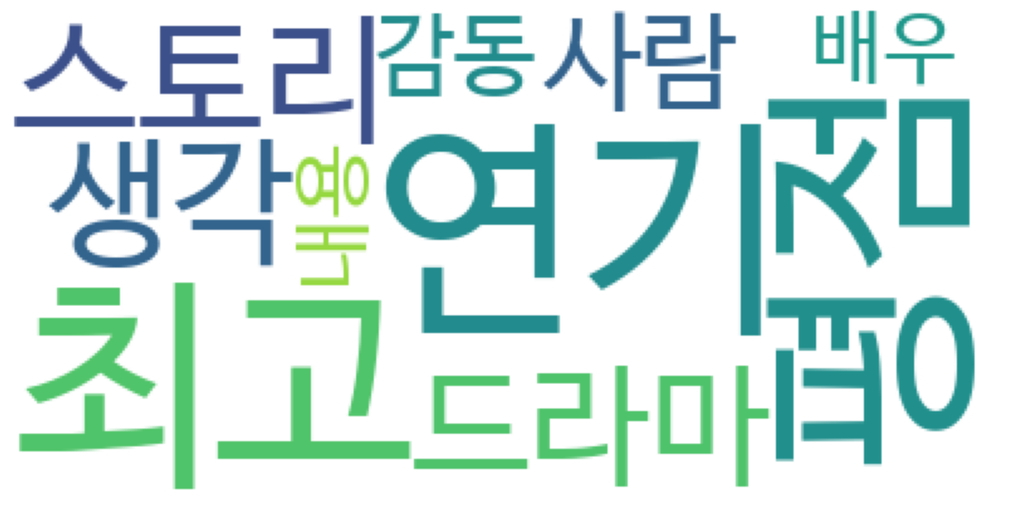

```python
figure = plt.figure(figsize = (14, 14))
ax = figure.add_subplot(1, 1, 1)
ax.axis('off')
ax.imshow(wc)
plt.show()
```

## 네이버 검색 API 서비스

### 네이버 서비스 API 신청

1. 네이버 개발자센터: https://developers.naver.com/
2. 어플리케이션 등록
3. 클라이언트 ID/SECRET 확인

### NAVER 서비스 API 종류

| 항목 | 주소 |
| --- | --- |
| 블로그 | https://openapi.naver.com/v1/search/blog.json |
| 뉴스 | https://openapi.naver.com/v1/search/news.json |
| 책 | https://openapi.naver.com/v1/search/book.json |
| 성인 검색어 판별 | https://openapi.naver.com/v1/search/adult.json |
| 백과사전 | https://openapi.naver.com/v1/search/encyc.json |
| 영화 | https://openapi.naver.com/v1/search/movie.json |
| 카페글 | https://openapi.naver.com/v1/search/cafearticle.json |
| 지식in | https://openapi.naver.com/v1/search/kin.json |
| 지역 | https://openapi.naver.com/v1/search/local.json |
| 오타변환 | https://openapi.naver.com/v1/search/errata.json |
| 웹문서 | https://openapi.naver.com/v1/search/webkr.json |
| 이미지 | https://openapi.naver.com/v1/search/image.json |
| 쇼핑 | https://openapi.naver.com/v1/search/shop.json |
| 전문자료 | https://openapi.naver.com/v1/search/doc.json |

## 네이버 웹문서 키워드 분석

### 네이버 웹문서 검색 API

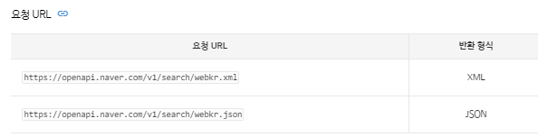

- 요청변수 (request parameter)

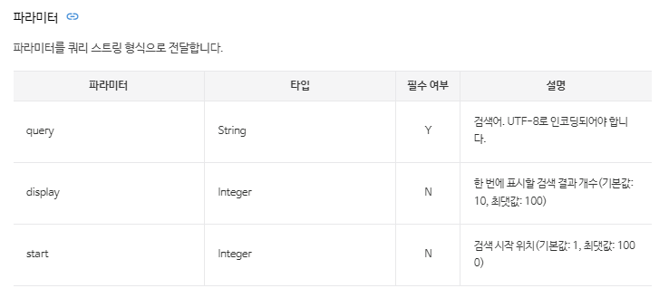

- 응답변수 (출력결과)

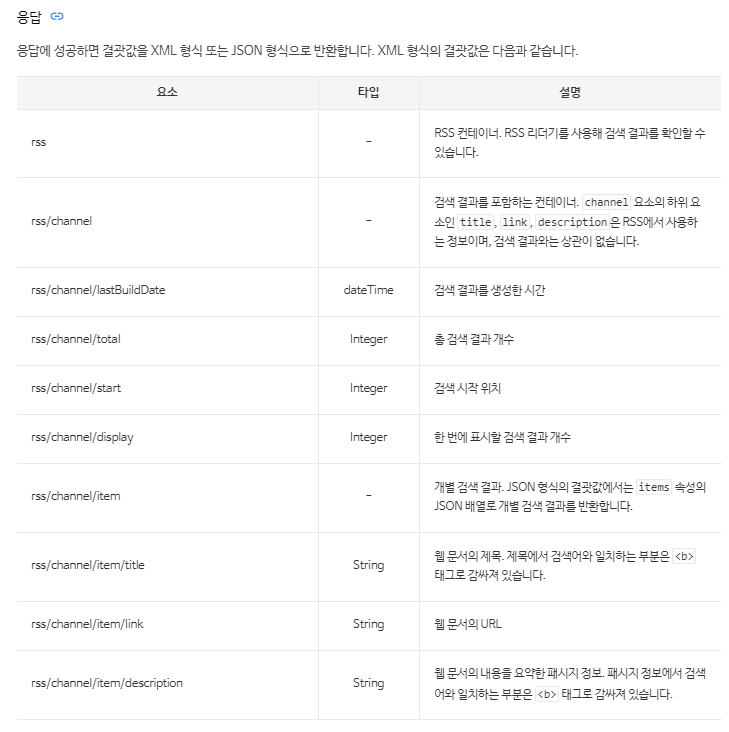

```python
import os
import sys
import urllib.request
import pandas as pd
import json
import re

client_id = 'vwDtkUQ04Naqe6Orz4DL' # API 토큰 ID
client_secret = 'j7ESYADcU3' # API 토큰 PW

query = urllib.parse.quote(input("검색 질의 : "))

# 검색결과를 할당할 DataFrame
web_df = pd.DataFrame(columns = ('Title', 'Link', 'Description'))

# DataFrame의 인덱스
idx = 0

# 한 번에 표시할 검색 결과 개수(기본값: 10, 최댓값: 100)
display = 100

# 검색 시작 위치(기본값: 1, 최댓값: 1000)
start = 1
end = 1000



for start_index in range(start, end, display):

  url = 'https://openapi.naver.com/v1/search/webkr?query=' + query \
    + '&display=' + str(display) + '&start=' + str(start_index)

  request = urllib.request.Request(url)
  request.add_header('X-Naver-Client-Id', client_id)
  request.add_header('X-Naver-Client-Secret', client_secret)
  response = urllib.request.urlopen(request)
  rescode = response.getcode()

  if(rescode == 200):
    response_body = response.read()
    response_dict = json.loads(response_body.decode('utf-8'))
    items = response_dict['items']

    for item_index in range(0, len(items)):
      remove_tag = re.compile('<.*?>')
      title = re.sub(remove_tag, '', items[item_index]['title'])
      link = items[item_index]['link']
      description = re.sub(remove_tag, '', items[item_index]['description'])
      web_df.loc[idx] = [title, link, description]

      idx += 1

  else:
    print('Error Code:' + rescode)
```

```
검색 질의 : 인공지능
```

```python
web_df.head()
```

|  | Title | Link | Description |
| --- | --- | --- | --- |
| 0 | 인공지능(AI) - 정책뉴스 \| 뉴스 \| 대한민국 정책브리핑 | https://www.korea.kr/special/policyCurationVie... | 세계는 인공지능(AI)의 급속한 발전으로 인해 산업과 사회 전반에... 이제는 인공... |
| 1 | 인공지능 - 나무위키 | https://namu.wiki/w/%EC%9D%B8%EA%B3%B5%EC%A7%8... | 인공지능(人工知能) 또는 A.I.(Artificial Intelligence)는 일... |
| 2 | 인공 지능 \| Dell Korea | https://www.dell.com/ko-kr/dt/solutions/artifi... | 솔루션 인공 지능 인공 지능 솔루션 AI로 모든 위치에서 지능적인 성과를 더 빠르게... |
| 3 | 인공 지능(AI)이란? \| 용어 해설 \| HPE 대한민국 | https://www.hpe.com/kr/ko/what-is/artificial-i... | AI(인공 지능)는 광범위하게 기계 또는 시스템이 하는 인간과 같은 모든 행동을 의... |
| 4 | 인공지능의 정의와 활용 방안 \| SAS KOREA | https://www.sas.com/ko_kr/insights/analytics/w... | SAS에서 인공지능(Artificial Intelligence)의 정의와 중요성, ... |

```python
web = []

for d in web_df['Description']:
  web.append(d)

print(web[:5])
```

```
['세계는 인공지능(AI)의 급속한 발전으로 인해 산업과 사회 전반에... 이제는 인공지능(AI)이 인간의 지적 능력을 수행하는 수준까지 발전했다. 인공지능(AI)은 막대한 부가가치를 창출하는 산업인 동시에...', '인공지능(人工知能) 또는 A.I.(Artificial Intelligence)는 일반적으로 인간의 학습능력, 추론능력, 지각능력이 필요한 작업을 할 수 있도록 컴퓨터시스템을 구현하려는 컴퓨터과학의 세부분야 중 하나이다. 인간을 포함한 동물이 갖고 있는 지능 즉, natural intelligence와는 다른 개념이다.…
```

### 형태소 분석을 이용한 명사 추출

#### 불용어 사전

불용어 예제: `인공지능 인공 지능 분야 수 것 등 기반 일 년 말 문 월 이 명 깨 개 중 범 부 딥 빅 책 분 봉 차 나 내 전 억 대 형 선 사 폼 원 번`

```python
stop_words = '인공지능 인공 지능 분야 수 것 등 기반 일 년 말 문 월 이 명 깨 개 중 범 부 딥 빅 책 분 봉 차 나 내 전 억 대 형 선 사 폼 원 번'.split(' ')
```

```python
tagger = Mecab()

web_nouns = []
for w in web:
  for noun in tagger.nouns(w):
    if noun not in stop_words:
      web_nouns.append(noun)

web_nouns[:10]
```

```
['세계', '급속', '발전', '산업', '사회', '전반', '이제', '인간', '지적', '능력']
```

### 단어 빈도수 측정

```python
web_nouns_counter = Counter(web_nouns)
top_web_nouns = dict(web_nouns_counter.most_common(10))
top_web_nouns
```

```
{'기술': 67,
 '인간': 46,
 '데이터': 44,
 '기업': 39,
 '컴퓨터': 38,
 '러닝': 34,
 '미래': 33,
 '학습': 30,
 '지원': 26,
 '과학': 25}
```

### 단어 빈도 시각화

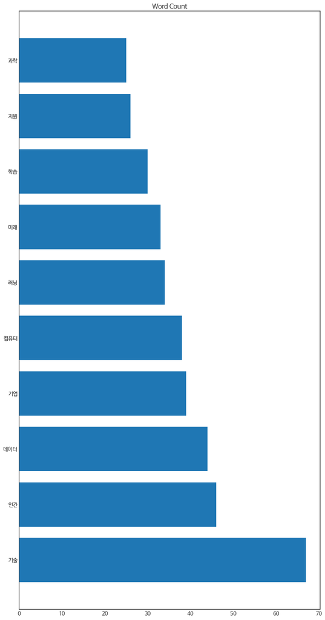

```python
plt.rcParams['font.size'] = 12

y_pos = np.arange(len(top_web_nouns))

plt.figure(figsize = (12, 24))
plt.barh(y_pos, top_web_nouns.values())
plt.title('Word Count')
plt.yticks(y_pos, top_web_nouns.keys())
plt.show()
```

### 트리맵 시각화

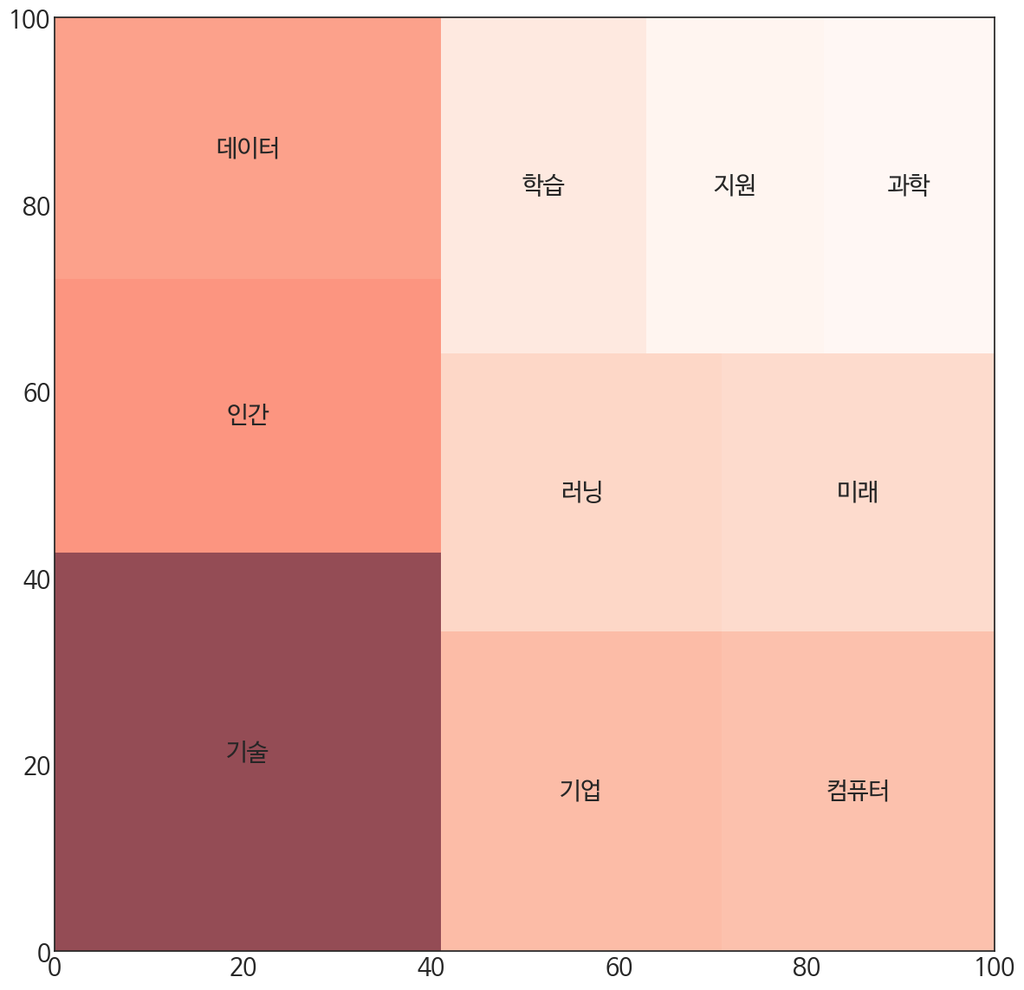

```python
plt.rcParams['figure.figsize'] = (14, 14)
plt.rcParams['font.size'] = 20

norm = mpl.colors.Normalize(vmin = min(top_web_nouns.values()),
                            vmax = max(top_web_nouns.values()))
color = [mpl.cm.Reds(norm(value)) for value in top_web_nouns.values()]

squarify.plot(label = top_web_nouns.keys(), sizes = top_web_nouns.values(),
              color = color, alpha = .7)
```

### 워드클라우드 시각화

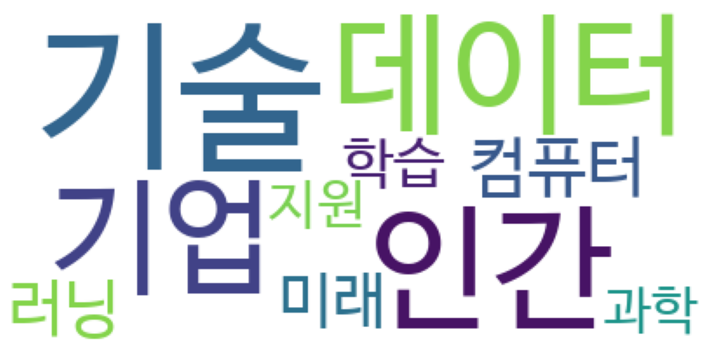

```python
wc = WordCloud(background_color = 'white', font_path = '/font/NanumBarunGothic.ttf')
wc.generate_from_frequencies(top_web_nouns)

figure = plt.figure(figsize = (14, 14))
ax = figure.add_subplot(1, 1, 1)
ax.axis('off')
ax.imshow(wc)
plt.show()
```

## 네이버 뉴스 키워드 분석

### 네이버 뉴스 검색 API

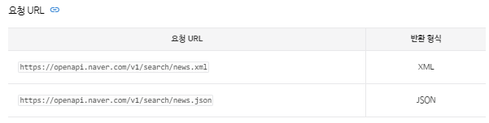

- 요청변수 (request parameter)

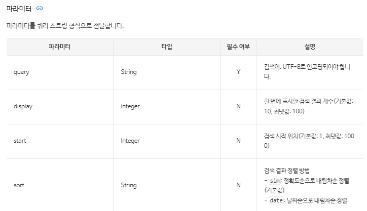

- 응답변수 (출력결과)

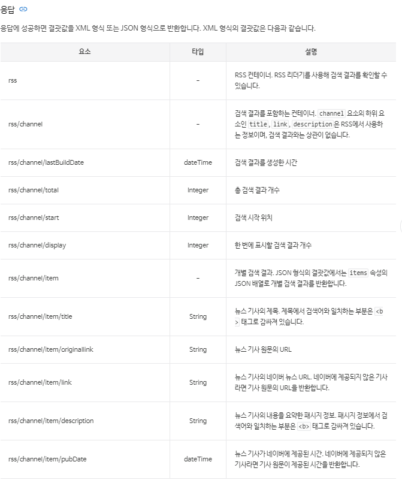

```python
query = urllib.parse.quote(input("검색 질의 : "))

# 검색결과를 할당할 DataFrame
news_df = pd.DataFrame(columns = ('Title', 'Original Link', 'Link', 'Description', 'Publication Date'))

# DataFrame의 인덱스
idx = 0

# 한 번에 표시할 검색 결과 개수(기본값: 10, 최댓값: 100)
display = 100

# 검색 시작 위치(기본값: 1, 최댓값: 1000)
start = 1
end = 1000

# 검색 결과 정렬 방법
sort = 'sim'



for start_index in range(start, end, display):

  url = 'https://openapi.naver.com/v1/search/news?query=' + query \
    + '&display=' + str(display) + '&start=' + str(start_index) + '&sort=' + str(sort)

  request = urllib.request.Request(url)
  request.add_header('X-Naver-Client-Id', client_id)
  request.add_header('X-Naver-Client-Secret', client_secret)
  response = urllib.request.urlopen(request)
  rescode = response.getcode()

  if(rescode == 200):
    response_body = response.read()
    response_dict = json.loads(response_body.decode('utf-8'))
    items = response_dict['items']

    for item_index in range(0, len(items)):
      remove_tag = re.compile('<.*?>')
      title = re.sub(remove_tag, '', items[item_index]['title'])
      original_link = items[item_index]['originallink']
      link = items[item_index]['link']
      description = re.sub(remove_tag, '', items[item_index]['description'])
      pubDate = items[item_index]['pubDate']
      news_df.loc[idx] = [title, original_link, link, description, pubDate]

      idx += 1

  else:
    print('Error Code:' + rescode)
```

```
검색 질의 : 인공지능
```

```python
news_df.head()
```

|  | Title | Original Link | Link | Description | Publication Date |
| --- | --- | --- | --- | --- | --- |
| 0 | 인공지능산업융합사업단, AI 스타트업 상용화 돕는다 | http://www.newsis.com/view/?id=NISX20230424_00... | https://n.news.naver.com/mnews/article/003/001... | 기사내용 요약 AI 제품·서비스 제작 및 상용화 지원사업 추진 인공지능(AI) 시제... | Mon, 24 Apr 2023 15:58:00 +0900 |
| 1 | SKT 인공지능 에이닷, 이루다 기술 장착...150억원 지분투자 | https://www.chosun.com/economy/economy_general... | https://n.news.naver.com/mnews/article/023/000... | SK텔레콤이 AI(인공지능) 챗봇 ‘이루다’로 유명한 스타트업 ‘스캐터랩’에 150... | Mon, 24 Apr 2023 09:43:00 +0900 |
| 2 | 국제미래학회 &apos;챗GPT 인공지능 실용 전문가&apos; 과정 성료 | https://www.etnews.com/20230424000138 | https://n.news.naver.com/mnews/article/030/000... | 국제미래학회가 인공지능(AI) &apos;챗GPT&apos;로 그림, 아바타, 시화... | Mon, 24 Apr 2023 12:16:00 +0900 |
| 3 | KT, 인공지능 화물 중개∙운송 플랫폼 &apos;브로캐리 2.0&apos; 출시 | https://www.businesspost.co.kr/BP?command=arti... | https://www.businesspost.co.kr/BP?command=arti... | KT는 디지털 물류전문 계열사인 롤랩과 협력을 통해 인공지능 기능이 대폭 강화된 화... | Mon, 24 Apr 2023 11:00:00 +0900 |
| 4 | 4월 22일 국내 최초로&apos;챗GPT 인공지능 실용 전문가&apos;1기 과정... | http://www.kyosu.net/news/articleView.html?idx... | http://www.kyosu.net/news/articleView.html?idx... | 국제미래학회 주최로 챗GPT 인공지능으로 그림, 아바타, 시나리오, 더빙, 동영상,... | Mon, 24 Apr 2023 14:46:00 +0900 |

```python
news = []

for n in news_df['Title']:
  news.append(n)

news[:5]
```

```
['인공지능산업융합사업단, AI 스타트업 상용화 돕는다',
 'SKT 인공지능 에이닷, 이루다 기술 장착...150억원 지분투자',
 '국제미래학회 &apos;챗GPT 인공지능 실용 전문가&apos; 과정 성료',
 'KT, 인공지능 화물 중개∙운송 플랫폼 &apos;브로캐리 2.0&apos; 출시',
 '4월 22일 국내 최초로&apos;챗GPT 인공지능 실용 전문가&apos;1기 과정 성황리에 개최']
```

### 형태소 분석을 이용한 명사 추출

```python
tagger = Mecab()

news_nouns = []
for n in news:
  for noun in tagger.nouns(w):
    if noun not in stop_words:
      news_nouns.append(noun)

news_nouns[:10]
```

```
['프로그램', '개요', '캠프', '고등', '회기', '상', '제주', '고등학교', '학생', '예비']
```

### 단어 빈도수 측정

```python
news_nouns_counter = Counter(news_nouns)
top_news_nouns = dict(news_nouns_counter.most_common(10))
top_news_nouns
```

```
{'시': 3000,
 '시간': 2000,
 '프로그램': 1000,
 '개요': 1000,
 '캠프': 1000,
 '고등': 1000,
 '회기': 1000,
 '상': 1000,
 '제주': 1000,
 '고등학교': 1000}
```

### 단어 빈도 시각화

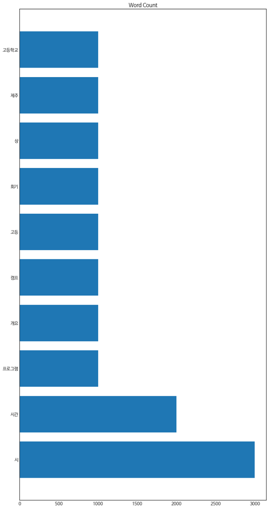

```python
plt.rcParams['font.size'] = 12

y_pos = np.arange(len(top_news_nouns))

plt.figure(figsize = (12, 24))
plt.barh(y_pos, top_news_nouns.values())
plt.title('Word Count')
plt.yticks(y_pos, top_news_nouns.keys())
plt.show()
```

### 트리맵 시각화

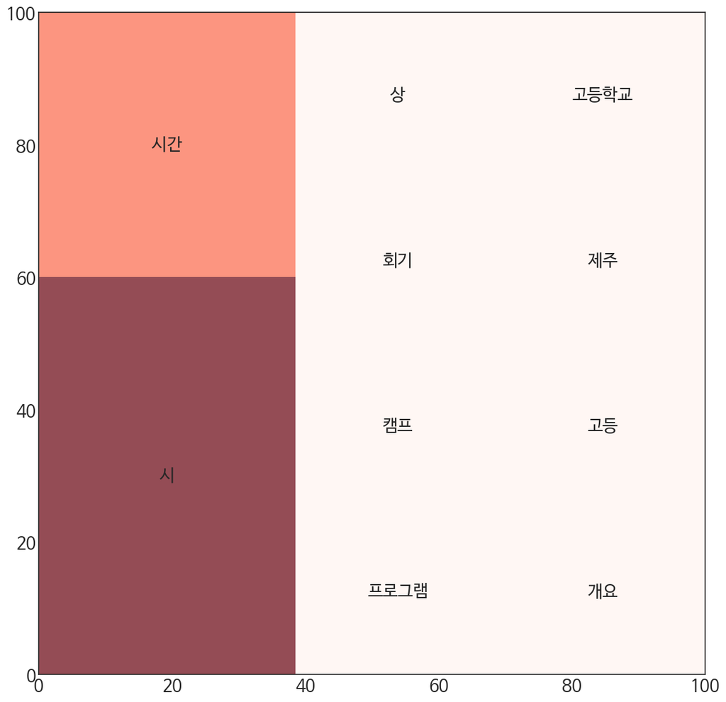

```python
plt.rcParams['figure.figsize'] = (14, 14)
plt.rcParams['font.size'] = 20

norm = mpl.colors.Normalize(vmin = min(top_news_nouns.values()),
                            vmax = max(top_news_nouns.values()))
color = [mpl.cm.Reds(norm(value)) for value in top_news_nouns.values()]

squarify.plot(label = top_news_nouns.keys(), sizes = top_news_nouns.values(),
              color = color, alpha = .7)
```

### 워드클라우드 시각화

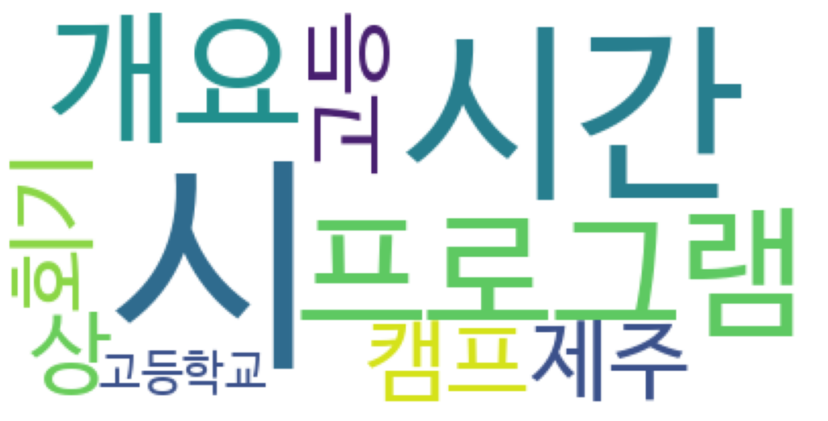

```python
wc = WordCloud(background_color = 'white', font_path = '/font/NanumBarunGothic.ttf')
wc.generate_from_frequencies(top_news_nouns)

figure = plt.figure(figsize = (14, 14))
ax = figure.add_subplot(1, 1, 1)
ax.axis('off')
ax.imshow(wc)
plt.show()
```

## 네이버 블로그 키워드 분석

### 네이버 블로그 검색 API

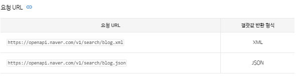

- 요청변수 (request parameter)

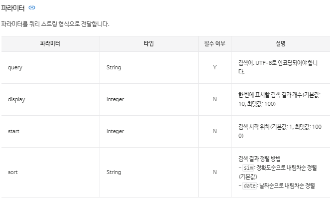

- 응답변수 (출력결과)

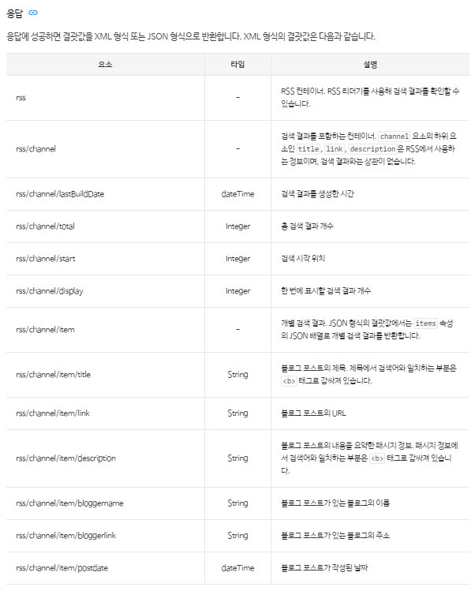

```python
query = urllib.parse.quote(input("검색 질의 : "))

# 검색결과를 할당할 DataFrame
blog_df = pd.DataFrame(columns = ('Title', 'Link', 'Description', 'Blogger Name', 'Blogger Link', 'Post Date'))

# DataFrame의 인덱스
idx = 0

# 한 번에 표시할 검색 결과 개수(기본값: 10, 최댓값: 100)
display = 100

# 검색 시작 위치(기본값: 1, 최댓값: 1000)
start = 1
end = 1000

# 검색 결과 정렬 방법
sort = 'sim'



for start_index in range(start, end, display):

  url = 'https://openapi.naver.com/v1/search/blog?query=' + query \
    + '&display=' + str(display) + '&start=' + str(start_index) + '&sort=' + str(sort)

  request = urllib.request.Request(url)
  request.add_header('X-Naver-Client-Id', client_id)
  request.add_header('X-Naver-Client-Secret', client_secret)
  response = urllib.request.urlopen(request)
  rescode = response.getcode()

  if(rescode == 200):
    response_body = response.read()
    response_dict = json.loads(response_body.decode('utf-8'))
    items = response_dict['items']

    for item_index in range(0, len(items)):
      remove_tag = re.compile('<.*?>')
      title = re.sub(remove_tag, '', items[item_index]['title'])
      link = items[item_index]['link']
      description = re.sub(remove_tag, '', items[item_index]['description'])
      blogger_name = items[item_index]['bloggername']
      blogger_link = items[item_index]['bloggerlink']
      postdate = items[item_index]['postdate']
      blog_df.loc[idx] = [title, link, description, blogger_name, blogger_link, postdate]

      idx += 1

  else:
    print('Error Code:' + rescode)
```

```
검색 질의 : 인공지능
```

```python
blog_df.head()
```

|  | Title | Link | Description | Blogger Name | Blogger Link | Post Date |
| --- | --- | --- | --- | --- | --- | --- |
| 0 | 그림 인공지능 사용해보기 | https://www.internetmap.kr/entry/Why-Generativ... | Stable Diffusion은 생성형 AI(인공지능), 그중에서도 단어를 입력하면... | 공간정보와 인터넷지도 | https://www.internetmap.kr/ | 20230326 |
| 1 | AI 인공지능 관련주 챗GPT 바드 - 춤을 추되 문 근처에서 춤을... | https://blog.naver.com/resumet/223016372983 | 개인적으로 인터넷이 불러온 3차 산업혁명 이후 4차의 주인공이 인공지능이 되지 않을... | 블루래더 - 경제적 자유를 향한 푸른 사다리 | blog.naver.com/resumet | 20230215 |
| 2 | AI 그림 그리기, Bing Image Creator로 인공지능 이미지... | https://blog.naver.com/winsweet/223068891384 | Bing 이미지 생성기는 검색 사이트와 유사한 인터페이스로 누구나 쉽게 인공지능 이... | Play IT | blog.naver.com/winsweet | 20230408 |
| 3 | 하남 미사 코딩학원 챗gpt AI 인공지능 프로그래밍 교육... | https://blog.naver.com/ijungsun/223078436832 | 요즘 IT관련 뉴스를 보시면 무조건 나오늘 말이 #챗gpt 와 #AI #인공지능 입... | IT&재미 | blog.naver.com/ijungsun | 20230418 |
| 4 | 후지의료기 인공 지능이 탑재된 JP-2000 안마의자 | https://blog.naver.com/wbstore/223079260672 | #후지의료기 #인공지능안마의자 #안마의자 안녕하세요 웰빙스토어 막내입니다:) 비 소... | 웰빙스토어 | blog.naver.com/wbstore | 20230419 |

```python
blog = []

for n in blog_df['Title']:
  blog.append(n)

blog[:5]
```

```
['그림 인공지능 사용해보기',
 'AI 인공지능 관련주 챗GPT 바드 - 춤을 추되 문 근처에서 춤을... ',
 'AI 그림 그리기, Bing Image Creator로 인공지능 이미지... ',
 '하남 미사 코딩학원 챗gpt AI 인공지능 프로그래밍 교육... ',
 '후지의료기 인공 지능이 탑재된 JP-2000 안마의자']
```

### 형태소 분석을 이용한 명사 추출

```python
tagger = Mecab()

blog_nouns = []
for b in blog:
  for noun in tagger.nouns(b):
    if noun not in stop_words:
      blog_nouns.append(noun)

blog_nouns[:10]
```

```
['그림', '사용', '관련', '주', '챗', '바드', '춤', '근처', '춤', '그림']
```

### 단어 빈도수 측정

```python
blog_nouns_counter = Counter(blog_nouns)
top_blog_nouns = dict(blog_nouns_counter.most_common(10))
top_blog_nouns
```

```
{'챗': 187,
 '시대': 77,
 '교육': 55,
 '활용': 55,
 '그림': 53,
 '미래': 46,
 '봇': 43,
 '관련': 37,
 '데이터': 37,
 '로봇': 36}
```

### 단어 빈도 시각화

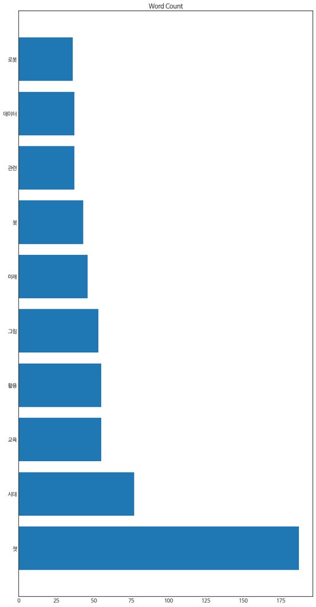

```python
plt.rcParams['font.size'] = 12

y_pos = np.arange(len(top_blog_nouns))

plt.figure(figsize = (12, 24))
plt.barh(y_pos, top_blog_nouns.values())
plt.title('Word Count')
plt.yticks(y_pos, top_blog_nouns.keys())
plt.show()
```

### 트리맵 시각화

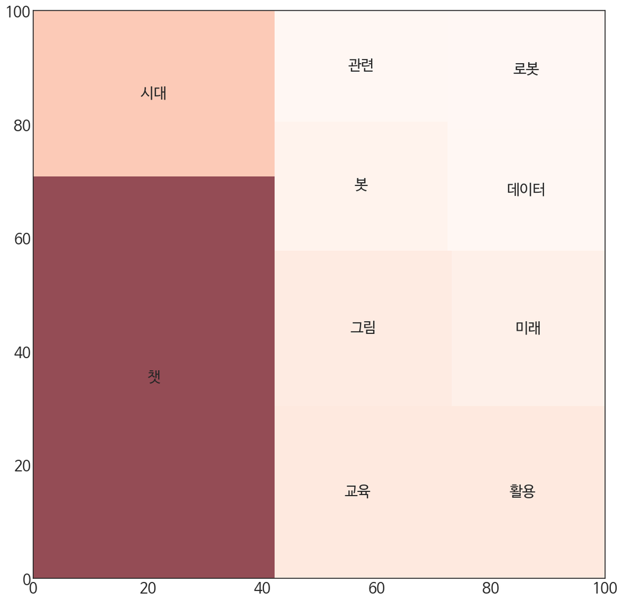

```python
plt.rcParams['figure.figsize'] = (14, 14)
plt.rcParams['font.size'] = 20

norm = mpl.colors.Normalize(vmin = min(top_blog_nouns.values()),
                            vmax = max(top_blog_nouns.values()))
color = [mpl.cm.Reds(norm(value)) for value in top_blog_nouns.values()]

squarify.plot(label = top_blog_nouns.keys(), sizes = top_blog_nouns.values(),
              color = color, alpha = .7)
```

### 워드클라우드 시각화

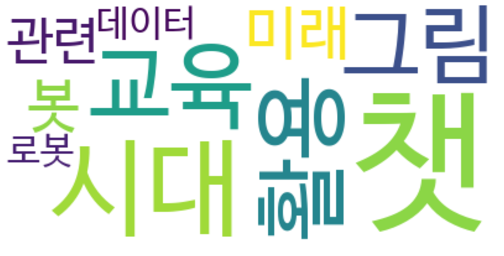

```python
wc = WordCloud(background_color = 'white', font_path = '/font/NanumBarunGothic.ttf')
wc.generate_from_frequencies(top_blog_nouns)

figure = plt.figure(figsize = (14, 14))
ax = figure.add_subplot(1, 1, 1)
ax.axis('off')
ax.imshow(wc)
plt.show()
```